#### Virtualisation et Cloud - © TEK-UP University

# LAB07 : Amazon Elastic Compute Cloud (EC2)

### Objectifs

Ce TP a pour objectif de familiariser l’étudiant avec les bases du service Amazon EC2 et d'acquérir les compétences essentielles pour déployer et administrer des serveurs virtuels dans un environnement cloud AWS. À la fin du TP, l’étudiant devra être capable de :

- Créer et configurer des instances EC2 de type Linux et Windows
- Se connecter à une instance Linux via SSH
- Se connecter à une instance Windows via RDP
- Déployer un serveur web sur Linux
- Déployer un serveur web sur Windows Server

# Partie 1 : Déploiement d’un serveur web Apache sur AWS EC2 sous Linux

1. Ouvrez la console Amazon EC2 puis, à partir du tableau de bord, cliquez sur "Launch Instance".

## 1.1. Création d'une instance EC2 Linux

### Étape 1 : Ajout des balises (tags)

Les balises permettent la catégorisation de vos instances. Ceci est utile si vous avez plusieurs instances du même type. Vous pouvez identifier une ressource par sa balise. Chaque balise consiste d'une clé et d'une valeur.

2. Dans la section "Name and Tags", ajoutez la balise suivante : Linux VM

### Étape 2 : Choix de l'AMI (Amazon Machine Image)

Une AMI (Amazon Machine Image) est un modèle qui contient les configurations logicielles requises pour lancer une instance. Vous pouvez :

- utiliser les AMI proposées par AWS ou par la communauté
- créer vos propres AMI personnalisées
- acheter des AMI auprès d'un tiers (AWS marketplace)

Une instance est une copie de l'AMI s'exécutant en tant que serveur virtuel dans le Cloud. À partir d'une AMI, on peut lancer une ou plusieurs instances.

[figure not shown]

3. Pour l'instance Linux sélectionnez l'AMI Amazon Linux 2

### Étape 3 : Choix du type d'instance

Dans cette étape vous allez sélectionner la configuration matérielle de votre instance.

Amazon EC2 fournit plusieurs types d'instances pour différents cas d'utilisation. Chaque type d'instance propose différentes capacités en terme de:

- puissance de calcul
- quantité de mémoire
- stockage
- performances réseau

Les types d'instance sont regroupés en familles d'instance en fonction de ces capacités:

- usage général (A1, T2, M4, etc.)
- calcul optimisé (C4, C5, etc.)
- mémoire optimisée (R6g, X1, mémoire élevée, etc.)
- calcul accéléré (P4, G3, etc.)
- stockage optimisé (I3, D2, H1, etc.)
4. Choisissez le type d’instance t3.micro qui est sélectionné par défaut.

### Étape 4 : Configuration de la paire de clés de sécurité

- Pour vous connecter à votre instance en toute securité, vous devez utiliser une paire de clés : publique (public key) enregistrée chez AWS et privée (private key) enregistrée sur votre machine. Les deux clés sont strictement associées et sont utilisées pour l'authentification de l'utilisateur et le chiffrement de la communication
  - Public key (clé publique) : stockée chez AWS
  - Private key (clé privée) : stockée chez l'utilisateur
5. Sélectionnez "Create new key pair" et donnez un nom à votre clé privée (par exemple "awskey"). Une fois créée, la clé privée est sauvegardée automatiquement dans le système de fichiers local de votre machine.

### Étape 5 : Configuration du groupe de sécurité

- Une instance EC2 a une adresse publique et ainsi accessible via Internet.
- Un groupe de sécurité joue le rôle de pare-feu (firewall) pour les instances associées, en contrôlant le trafic entrant et le trafic sortant au niveau de l'instance (en fonction des protocoles et des numéros de port).
- Les groupes de sécurité sont avec état (stateful) et vous pouvez indiquer des règles d'autorisation, mais pas des règles d'interdiction.
- Les régles à ajouter seront applicables sur chaque machine associée au groupe de sécurité. Vous pouvez modifier ces régles à tout moment (effet immediat!).

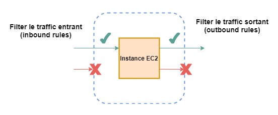

- Lorsque vous créez une instance, vous devez l'associer à un groupe de sécurité. Si vous ne spécifiez pas un autre groupe de sécurité lorsque vous lancez l'instance, celle-ci est automatiquement associée au groupe de sécurité par défaut.
6. Ajoutez des règles qui vous permettent de vous connecter à votre instance Linux : le protocole SSH (Secure Shell), (port 22)

### Étape 6 : Configuration du stockage

- Toutes les AMI sont réparties en deux catégories : basées sur Amazon EBS ou basées sur le stockage d'instance (Instance Store). Amazon EBS fournit des volumes de stockage de type bloc qui peuvent persister indépendamment de la durée d'exécution d'une instance. Contrairemnt au stockage d'instances qui fournit un stockage temporaire de type bloc. Les données stockées dans un stockage d'instance sont supprimées quand vous arrêtez, mettez en veille prolongée ou résiliez votre instance.

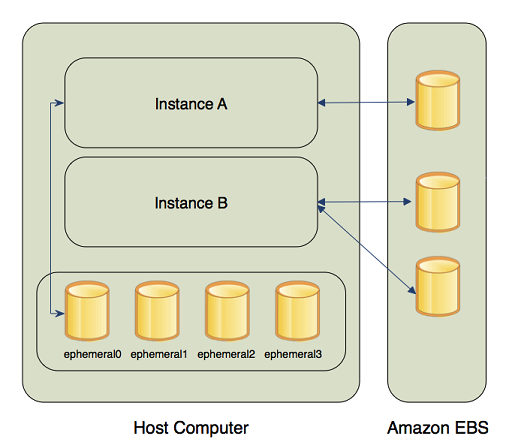

7. Sur la fenetre "Storage (volumes)", examinez les détails relatifs au stockage de l'instance : vous allez lancer votre instance en utilisant un disque EBS (Elastic Block Store) de taille 8 Go qui sera votre disque racine.

### Étape 7 : Vérification

8. Examinez les détails de votre instance puis cliquez sur le bouton "Launch".

## 1.2. Connexion à l'instance Linux

9. À partir du tableau de bord EC2, sélectionnez votre instance, cliquez sur Connect, puis suivez les instructions de l’onglet SSH client pour ouvrir un terminal sur l’instance EC2.

## 1.3. Installation du serveur web Apache

10. Dans le terminal de votre instance EC2, tapez les commandes suivantes pour installer leserveur web apache (httpd) :

```
sudo su
yum update -y
yum -y install httpd
systemctl enable httpd
systemctl start httpd
echo '<html><h1> Hello From AWS!</h1></html>' > /var/www/html/index.html
```

## 1.4. Automatisation via les User Data de l’instance

```
#!/bin/bash
yum update -y
yum -y install httpd
systemctl enable httpd
systemctl start httpd
echo '<html><h1> Hello From AWS!</h1></html>' > /var/www/html/index.html
```

## 1.5. Cycle de vie d'une instance

Une instance Amazon EC2 passe par différents états. L'illustration suivante représente les transitions entre les états de l'instance. Vous ne pouvez arrêter et démarrer que les instance basée sur les volumes EBS (cela n'est pas possible avec celles basées sur le stockage d'instance).

[figure not shown]

Bonne pratique : pour cesser d'accumuler les frais, n'oubliez pas d'arrêter ou de supprimer les instances EC2 dont vous n'avez plus besoin (vérifier dans différentes régions)

## 1.6. Adressage IP des instances Amazon EC2

Par défaut, Amazon EC2 utilise le protocole adressage IPv4 (prend en charge aussi le protocole IPv6).

[output not shown]

- Si vous avez besoin d'une adresse IP publique permanente vous devez associez une adresse IP élastique à votre instance.
- Pour allouer une adresse IP élastique et l'associer à votre instance, suivez les étapes suivantes :
16. Choisissez "Elastic IPs" dans le volet de navigation à gauche, puis cliquez sur "Allocate Elastic IP address". Garder la configuration par défaut et cliquez sur "Allocate"
17. Cliquez sur "Actions" puis sur "Associate Elastic IP address", sélectionnez "Instance" comme "Resource type" et cherchez votre instance dans la liste déroulante puis cliquez sur "Associate".
18. Ouvrez la liste des instances, et vérifiez que votre instance possède maintenant une adresse IP élastique.

# Partie 2 : Déploiement d’un serveur web IIS sur AWS EC2 avec Windows Server

## 2.1. Création d'une instance EC2 Windows

1. Créez une nouvelle instance avec les paramètres suivants :
- Balise : Serveur-Web-IIS
- AMI : Windows Server 2025 base
- Type instance : t3.micro
- Paire de clés : utilisez la clé que vous avez créeé dans la première partie
- Groupe de sécurité : autorisez l'accès RDP (port 3389)
- Stockage : 30 Go (par défaut)

## 2.2. Connexion à l'instance Windows

- Vous pouvez vous connecter à votre instance Windows à l'aide d'un client RDP.
2. Sélectionnez votre instance dans la liste des instances puis cliquez sur "Connect"
3. Sur la page "Connect to instance", sélectionnez l'onglet "RDP client" puis cliquez sur "Get password" pour obtenir un mot de passe. Il faut attendre quelques minutes après le lancement de l'instance pour que ce mot de passe soit disponible.
4. Cherchez votre fichier de clé privée (.pem) que vous avez créé lors du lancement de l'instance et cliquez sur "Open". Puis choisissez "Decrypt Password" pour affichez votre mot de passe.
5. Ouvrez votre client RDP et spécifier les valeurs suivantes :
   - User Name : "Administrator" (ou "Administrateur" pour le français)
   - Password : le mot de passe que vous avez obtenu
6. Cliquez sur "OK" puis "Yes" pour ouvrir votre instance Windows.

## 2.3. Installation et configuration d’IIS

7. Une fois connecté à votre instance, ouvrez le Gestionnaire de Serveur

[figure not shown]

8. Cliquez sur Ajouter des rôles et des fonctionnalités.
9. Dans l’Assistant d’installation :
- Sélectionnez Installation basée sur un rôle.
- Choisissez le serveur local.
- Dans Rôles de serveur, cochez Serveur Web (IIS).
- Acceptez les fonctionnalités par défaut et cliquez sur Suivant.
- Cliquez sur Installer et attendez la fin du processus.

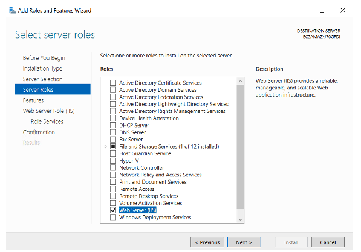

10. Une fois l’installation terminée, ouvrez Internet Information Services (IIS) Manager via le menu Démarrer.
11. Démarrez le service IIS si ce n’est pas déjà fait.
12. Ouvrez un navigateur et tapez http://localhost pour vérifier que la page IIS s'affiche.

## 2.4. Tester l’accès depuis Internet

13. Dans la console AWS, notez l’adresse IP publique de votre instance.
14. Ouvrez un navigateur sur votre machine locale et tapez : `http://[IP-PUBLIQUE-DE-L'INSTANCE]`
15. Mettre à jour le groupe de sécurité : Ajoutez une règle HTTP (port 80, ouvert à tous) pour accéder au serveur web.
16. Actualisez la page web, vous devriez maintenant voir la page d’accueil par défaut d’IIS.

[figure not shown]

## 2.5. Personnalisation de la page d’accueil IIS (Optionnel)

17. Sur l’instance Windows Server, accédez au répertoire : `C:\inetpub\wwwroot`
18. Ouvrez `iisstart.htm` avec Notepad et modifiez le contenu.
19. Sauvegardez et rafraîchissez la page dans le navigateur pour voir les changements.